# R Notebook

## cross validation is a way to estimate the generalization error.

##In this exercise we will implement the cross validation method from scratch. ## We want to perform a regression of the form Y ∼ Σ χk (the summation is from k= 1 to d) and use cross validation as a method to identify the optimal d.

## We first construct our dataset in the following way: -

## Sample a vector X ∈ R^n where each Xi ∈ U[0, 1]. Each sample point Xi is sampled from the uniform distribution. Construct Y from X using the following equation

##Y = 3X⁵ + 2X² + ϵ

##where ϵ ∈ R^n ##Each ϵi is sampled independently from the N(0,0.5) (normal distribution). ##Choose n = 10000.

```r
set.seed(1234)  ## to make sure our randomly selected errors are replicated throughout the code

X <- runif(10000,0,1)

Y <-  (3 * X^5) + (2 * X^2) + (rnorm(10000, 0, 0.5))

data <- data.frame(X,Y)
```

##Split the 10000 points into a 80% training and 20% test split.

```r
# download required data and packages

library(caTools)
library(glmnet)
library(dplyr)
# Use a seed before randomizing to replicate results.
set.seed(1234)

data$id <- 1:nrow(data)

# Split the data into train(80% of data) and test (20% of data)

train_data <- data %>% dplyr::sample_frac(0.8)
test_data <- dplyr::anti_join(data, train_data, by='id')

dim(train_data)
```

```
## [1] 8000    3
```

```r
dim(test_data)
```

```
## [1] 2000    3
```

```r
train_data2 <- train_data[,1:2]
test_data2 <- test_data[,1:2]
```

## Split the training set into 5 parts and use the five folds to choose the

## optimal d. The loss function we would implement is the MSE error.

## You want to estimate the MSE error on each fold for a model that has

## been trained on the remaining 4 folds. The cross validation (CV) error

## for the training set would be the average MSE across all five folds.

```r
#number of folds
k <- 5

#  values of d
d_vals <- 1:10

# Split the train data into 5 folds
folds <- split(train_data2, rep(1:k, length.out=nrow(train_data2)))
#class(folds)

# vector to store the CV errors for each value of d
cv_errors <- numeric(length(d_vals))

# For loop for each value of d
for (i in 1:length(d_vals)) {

  d <- d_vals[i]  # Get the current value of d
  mse_errors <- numeric(k)   # Initialize a vector to store the MSE errors for each fold

  # For loop for each of 5 folds
  for (j in 1:k) {

    val_data <- folds[[j]] # Get the jth fold as the validation set
    train_folds <- folds[-j] # Get the remaining folds as the training set
    train_data3 <- do.call(rbind, train_folds)
    model3 <- lm(Y ~ poly(X, d), data=list(train_data3)) #Fit a polynomial reg model with current value of d
    preds3 <- predict(model3, newdata=val_data) # Calculate the MSE error on the validation set
    mse_errors[j] <- mean((val_data$Y - preds3)^2)
  }

  cv_errors[i] <- mean(mse_errors) # Calculate the avg MSE error across all folds
}

cv_errors
```

```
##  [1] 0.5665806 0.2757987 0.2488949 0.2479024 0.2478720 0.2478717 0.2478728
##  [8] 0.2478594 0.2478039 0.2478051
```

## Plot the CV error as a function of d for d ∈ [1, 2, . . . , 10]

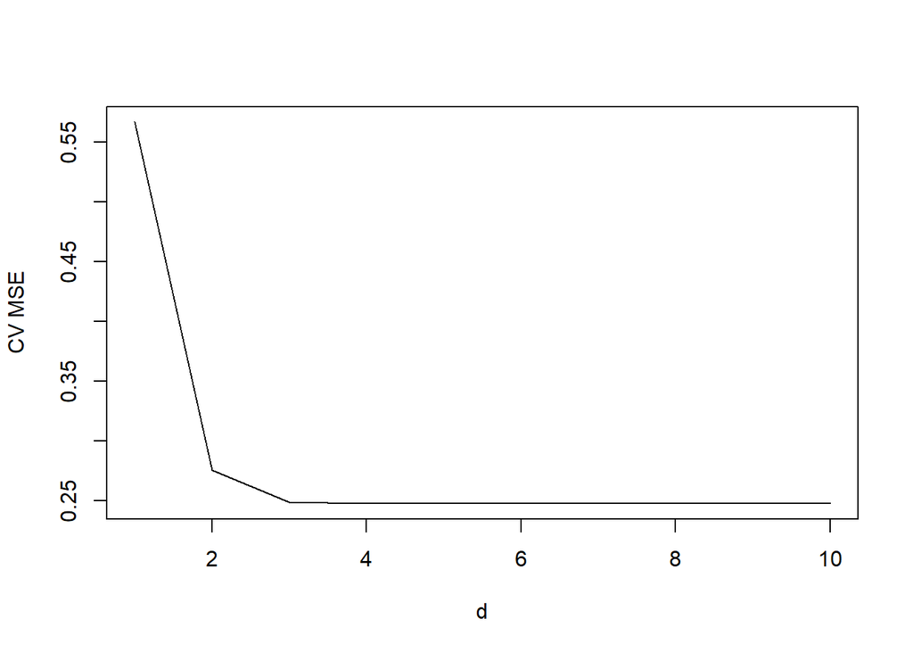

```r
# Plot the CV error as a function of d
plot(d_vals, cv_errors, type="l", xlab="d", ylab="CV MSE")
```

```r
sprintf("From the graph, as the value of d increases, the average MSE from cv is decreasing. Fron d=4, the avg MSE is more or less constant.")
```

```
## [1] "From the graph, as the value of d increases, the average MSE from cv is decreasing. Fron d=4, the avg MSE is more or less constant."
```